# vtreat_gardenpath

Nina Zumel

November 10, 2015

A simple example of running vtreat.

```r
library(vtreat)
library(ggplot2)
```

Functions for generating the data

```r
make_cats = function() {
  small_cat = c("red", "blue", "green", "pink", "magenta")
  sc_means = 3*runif(length(small_cat))
  names(sc_means) = small_cat
  sc_probs = c(0.3, 0.3, 0.3, 0.05, 0.05)

  large_cat = paste("v", 1:200, sep="_")
  lc_means = 2*runif(length(large_cat))
  names(lc_means) = large_cat

  list(sc_means=sc_means,
       sc_probs=sc_probs,
       lc_means=lc_means)
}

make_data = function(N, na_rate,
                     sc_means, sc_probs,
                     lc_means) {

  small_cat = names(sc_means)
  large_cat = names(lc_means)

  x1 = rnorm(N)
  x1 = ifelse(runif(N) < na_rate, NA, x1)

  x2 = sample(small_cat, size=N, replace=TRUE, prob=sc_probs)
  x3 = sample(large_cat, size=N, replace=TRUE)

  y = ifelse(is.na(x1), -1, x1) +
    sc_means[x2] +
    lc_means[x3] + rnorm(N)

  data.frame(x1=x1, x2=x2, x3=x3, y = y)

}
```

Make the data

```r
set.seed(233542)
cats = make_cats()
na_rate = 0.01

train = make_data(1000, na_rate, cats$sc_means, cats$sc_probs, cats$lc_means)
calib = make_data(500, na_rate, cats$sc_means, cats$sc_probs, cats$lc_means)
calibBig = make_data(2000, na_rate, cats$sc_means, cats$sc_probs, cats$lc_means)
test = make_data(1000, na_rate, cats$sc_means, cats$sc_probs, cats$lc_means)
```

Try to naively fit an lm. We have to guard against levels possibly not showing up in test, and against rows not being scored because of a NA in the input.

```r
fmla = "y ~ x1 + x2 + x3"
model = lm(fmla, data=train)

# lots of coefficients, too long to want to print the summary
print(paste(length(model$coefficients), "coefficients"))
```

```
## [1] "205 coefficients"
```

```r
smod = summary(model)
print(paste("R-squared = ", smod$r.squared, "Adjusted R-squared = ", smod$adj.r.squared))
```

```
## [1] "R-squared =  0.7632051574766 Adjusted R-squared =  0.701902939361405"
```

```r
# this may fail because of novel levels
test$pred = tryCatch(
      predict(model, newdata=test),
      error=function(e) {print(e); NULL}
)

# we have to put a guard here for the test rows where x1 is NA
rmse = sqrt(mean((test$y - test$pred)^2, na.rm=TRUE))
print(paste("mean(y) = ", mean(test$y), "stdev(y) = ", sd(test$y), "rmse = ", rmse))
```

```
## [1] "mean(y) =  2.1481783784283 stdev(y) =  1.73912328881798 rmse =  1.17127237465778"
```

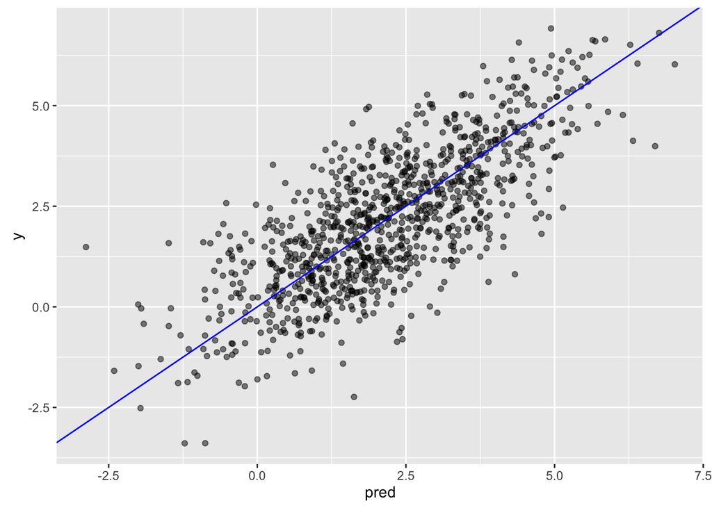

```r
ggplot(test, aes(x=pred, y=y)) + geom_point(alpha=0.5) + geom_abline(color="blue")
```

Now with vtreat. First, the default settings

```r
outcome = "y"
varlist = setdiff(colnames(calib), outcome)

# try this with just the default settings
treatplan = designTreatmentsN(calib, varlist, outcome)
```

```
## [1] "desigining treatments Sat Apr 30 07:45:02 2016"
## [1] "design var x1 Sat Apr 30 07:45:02 2016"
## [1] "design var x2 Sat Apr 30 07:45:02 2016"
## [1] "design var x3 Sat Apr 30 07:45:02 2016"
## [1] "scoring treatments Sat Apr 30 07:45:02 2016"
## [1] "have treatment plan Sat Apr 30 07:45:02 2016"
## [1] "rescoring complex variables Sat Apr 30 07:45:02 2016"
## [1] "done rescoring complex variables Sat Apr 30 07:45:03 2016"
```

```r
# look at the score frame
print(treatplan$scoreFrame)
```

```
##             varName varMoves         psig          sig needsSplit origName
## 1          x1_clean     TRUE 7.308139e-41 7.308139e-41      FALSE       x1
## 2          x1_isBAD     TRUE 2.382227e-02 2.382227e-02      FALSE       x1
## 3     x2_lev_x.blue     TRUE 3.217482e-07 3.217482e-07      FALSE       x2
## 4    x2_lev_x.green     TRUE 6.873107e-32 6.873107e-32      FALSE       x2
## 5  x2_lev_x.magenta     TRUE 5.484302e-01 5.484302e-01      FALSE       x2
## 6     x2_lev_x.pink     TRUE 8.326459e-01 8.326459e-01      FALSE       x2
## 7      x2_lev_x.red     TRUE 4.510644e-08 4.510644e-08      FALSE       x2
## 8           x2_catP     TRUE 2.726747e-02 2.726747e-02       TRUE       x2
## 9           x2_catN     TRUE 1.606779e-30 1.606779e-30       TRUE       x2
## 10          x2_catD     TRUE 4.087594e-02 4.087594e-02       TRUE       x2
## 11          x3_catP     TRUE 9.154134e-01 9.154134e-01       TRUE       x3
## 12          x3_catN     TRUE 7.383048e-02 7.383048e-02       TRUE       x3
## 13          x3_catD     TRUE 8.864614e-01 8.864614e-01       TRUE       x3
##     code
## 1  clean
## 2  isBAD
## 3    lev
## 4    lev
## 5    lev
## 6    lev
## 7    lev
## 8   catP
## 9   catN
## 10  catD
## 11  catP
## 12  catN
## 13  catD
```

The sig column of scoreFrame gives the significance of a variable against the null hypothesis that the variable has no relation to the outcome. You can see that x3 looks insignificant (even though we know it carries signal), because 500 rows of calibration is not enough to get good estimates of 200 levels that occur uniformly, (each level appears an average of 2.5 times in calib).

The column x3_catN impact codes all the non-rare levels (those that appeared more than 2 times), which individually still don’t occur very often, so the resulting impact model is unreliable; vtreat detects this on cross validation, and assigns a poor significance value to the column.

A bigger calibration set will mitigate these issues, because individual x3 levels will occur more often.

```r
treatplan = designTreatmentsN(calibBig, varlist, outcome)
```

```
## [1] "desigining treatments Sat Apr 30 07:45:03 2016"
## [1] "design var x1 Sat Apr 30 07:45:03 2016"
## [1] "design var x2 Sat Apr 30 07:45:03 2016"
## [1] "design var x3 Sat Apr 30 07:45:03 2016"
## [1] "scoring treatments Sat Apr 30 07:45:03 2016"
## [1] "have treatment plan Sat Apr 30 07:45:03 2016"
## [1] "rescoring complex variables Sat Apr 30 07:45:03 2016"
## [1] "done rescoring complex variables Sat Apr 30 07:45:03 2016"
```

```r
print(treatplan$scoreFrame)
```

```
##             varName varMoves          psig           sig needsSplit
## 1          x1_clean     TRUE 6.371996e-156 6.371996e-156      FALSE
## 2          x1_isBAD     TRUE  9.248064e-06  9.248064e-06      FALSE
## 3     x2_lev_x.blue     TRUE  2.572766e-34  2.572766e-34      FALSE
## 4    x2_lev_x.green     TRUE 3.556343e-107 3.556343e-107      FALSE
## 5  x2_lev_x.magenta     TRUE  4.761115e-01  4.761115e-01      FALSE
## 6     x2_lev_x.pink     TRUE  2.538715e-01  2.538715e-01      FALSE
## 7      x2_lev_x.red     TRUE  2.180142e-19  2.180142e-19      FALSE
## 8           x2_catP     TRUE  5.991245e-01  5.991245e-01       TRUE
## 9           x2_catN     TRUE 2.372813e-113 2.372813e-113       TRUE
## 10          x2_catD     TRUE  4.975551e-84  4.975551e-84       TRUE
## 11          x3_catP     TRUE  1.807864e-01  1.807864e-01       TRUE
## 12          x3_catN     TRUE  2.616957e-18  2.616957e-18       TRUE
## 13          x3_catD     TRUE  9.319711e-02  9.319711e-02       TRUE
##    origName  code
## 1        x1 clean
## 2        x1 isBAD
## 3        x2   lev
## 4        x2   lev
## 5        x2   lev
## 6        x2   lev
## 7        x2   lev
## 8        x2  catP
## 9        x2  catN
## 10       x2  catD
## 11       x3  catP
## 12       x3  catN
## 13       x3  catD
```

Takeaway: if you have categorical variables with many levels, you need data sets big enough to see all possible values.

Once you have the treatment plan, you must prepare the data sets. Note: at this point we can use the pruneSig parameter to further suppress insignificant indicator variables. Having both controls gives us more flexibility in designing impact and indicator variables. For example, we can leave rareSig loose to allow low-significance levels into the impact coding, but then use a stricter pruneSig to suppress their matching indicator variables from the modeling.

```r
# pruneSig: prune variables with p-value larger than this value.
# You can turn off pruning completely with pruneSig=NULL
# doCollar (default TRUE) restricts numeric variables to be in the range observed in the calibration data
train_treat = prepare(treatplan, train, pruneSig=0.05, doCollar=FALSE)
test_treat = prepare(treatplan, test, pruneSig=0.05, doCollar=FALSE)

print(colnames(train_treat))
```

```
## [1] "x1_clean"       "x1_isBAD"       "x2_lev_x.blue"  "x2_lev_x.green"
## [5] "x2_lev_x.red"   "x2_catN"        "x2_catD"        "x3_catN"
## [9] "y"
```

```r
# Since we're doing an lm(), don't use the catN variable (because it is colinear with the indicator variables)
vars = setdiff(colnames(train_treat), c(outcome, "x2_catN"))

fmla = paste(outcome, paste(vars, collapse=" + "), sep = " ~ ")

model = lm(fmla, data=train_treat)
summary(model)
```

```
##
## Call:
## lm(formula = fmla, data = train_treat)
##
## Residuals:
##     Min      1Q  Median      3Q     Max
## -3.6655 -0.7381 -0.0343  0.7253  3.2931
##
## Coefficients:
##                 Estimate Std. Error t value Pr(>|t|)
## (Intercept)     57.33883   19.96272   2.872 0.004162 **
## x1_clean         1.06933    0.03269  32.707  < 2e-16 ***
## x1_isBAD        -1.56849    0.40649  -3.859 0.000121 ***
## x2_lev_x.blue   -2.31750    0.49318  -4.699 2.98e-06 ***
## x2_lev_x.green   6.34035    1.95650   3.241 0.001232 **
## x2_lev_x.red     0.60384    0.54565   1.107 0.268717
## x2_catD        -36.75428   13.37934  -2.747 0.006122 **
## x3_catN          0.55675    0.04325  12.873  < 2e-16 ***
## ---
## Signif. codes:  0 '***' 0.001 '**' 0.01 '*' 0.05 '.' 0.1 ' ' 1
##
## Residual standard error: 1.069 on 992 degrees of freedom
## Multiple R-squared:  0.6617, Adjusted R-squared:  0.6593
## F-statistic: 277.1 on 7 and 992 DF,  p-value: < 2.2e-16
```

```r
test$pred = predict(model, newdata=test_treat)

rmse = sqrt(mean((test$y - test$pred)^2))
print(paste("mean(y) = ", mean(test$y), "stdev(y) = ", sd(test$y), "rmse = ", rmse))
```

```
## [1] "mean(y) =  2.1481783784283 stdev(y) =  1.73912328881798 rmse =  1.086772924313"
```

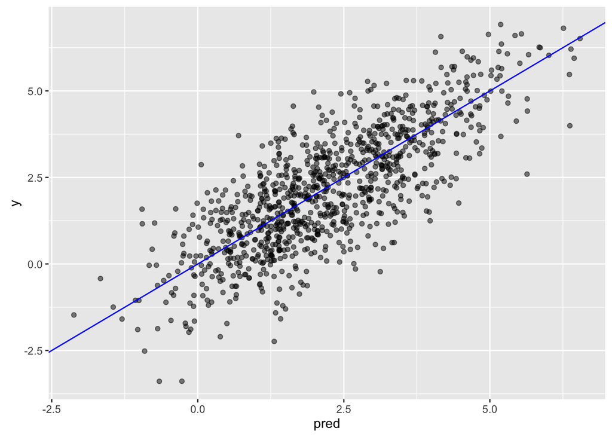

```r
ggplot(test, aes(x=pred, y=y)) + geom_point(alpha=0.5) + geom_abline(color="blue")
```